# Olympic games project

Ivan Semenov

11/7/2021

In this analysis, we will be looking at the different characteristics of the participants of the Olympic Games.

## 1. Libraries installation

```r
if(!require(dplyr)) install.packages("dplyr")
if(!require(psych)) install.packages("psych")
if(!require(psych)) install.packages("tidyr")
if(!require(ggplot2)) install.packages("ggplot2")
if(!require(ggpubr)) install.packages("ggpubr")
if(!require(corrplot)) install.packages("corrplot")
if(!require(tableHTML)) install.packages("tableHTML")

library(dplyr)
library(psych)
library(tidyr)
library(ggplot2)
library(ggpubr)
library(corrplot)
library(tableHTML)
```

## 2. Data Loading

Here we provide a function *read_files* which combines separate files from a directory into one data frame. It reuqires 2 parameters: path (path to the directory where required files are located) and format (type of files to combine).

```r
read_files <- function(format, path="./"){

  pattern = paste("*.", format, sep="")
  data_all <- list.files(path = path, pattern = pattern, full.names = TRUE) %>%
    lapply(read.csv) %>% bind_rows
  return(data_all)
}
```

Load data

```r
my_data <- read_files("csv")
tableHTML(head(my_data))
```

|  | ID | Name | Sex | Age | Height | Weight | Team | NOC | Games | Year | Season | City | Sport | Event | Medal |
| --- | --- | --- | --- | --- | --- | --- | --- | --- | --- | --- | --- | --- | --- | --- | --- |
| 1 | 1 | A Dijiang | M | 24 | 180 | 80 | China | CHN | 1992 Summer | 1992 | Summer | Barcelona | Basketball | Basketball Men's Basketball | NA |
| 2 | 2 | A Lamusi | M | 23 | 170 | 60 | China | CHN | 2012 Summer | 2012 | Summer | London | Judo | Judo Men's Extra-Lightweight | NA |
| 3 | 3 | Gunnar Nielsen Aaby | M | 24 | NA | NA | Denmark | DEN | 1920 Summer | 1920 | Summer | Antwerpen | Football | Football Men's Football | NA |
| 4 | 4 | Edgar Lindenau Aabye | M | 34 | NA | NA | Denmark/Sweden | DEN | 1900 Summer | 1900 | Summer | Paris | Tug-Of-War | Tug-Of-War Men's Tug-Of-War | Gold |
| 5 | 5 | Christine Jacoba Aaftink | F | 21 | 185 | 82 | Netherlands | NED | 1988 Winter | 1988 | Winter | Calgary | Speed Skating | Speed Skating Women's 500 metres | NA |
| 6 | 5 | Christine Jacoba Aaftink | F | 21 | 185 | 82 | Netherlands | NED | 1988 Winter | 1988 | Winter | Calgary | Speed Skating | Speed Skating Women's 1,000 metres | NA |

Look at data frame structure

```r
dplyr::glimpse(my_data)
```

```
## Rows: 271,115
## Columns: 15
## $ ID     <int> 1, 2, 3, 4, 5, 5, 5, 5, 5, 5, 6, 6, 6, 6, 6, 6, 6, 6, 7, 7, 7, …
## $ Name   <chr> "A Dijiang", "A Lamusi", "Gunnar Nielsen Aaby", "Edgar Lindenau…
## $ Sex    <chr> "M", "M", "M", "M", "F", "F", "F", "F", "F", "F", "M", "M", "M"…
## $ Age    <int> 24, 23, 24, 34, 21, 21, 25, 25, 27, 27, 31, 31, 31, 31, 33, 33,…
## $ Height <int> 180, 170, NA, NA, 185, 185, 185, 185, 185, 185, 188, 188, 188, …
## $ Weight <dbl> 80, 60, NA, NA, 82, 82, 82, 82, 82, 82, 75, 75, 75, 75, 75, 75,…
## $ Team   <chr> "China", "China", "Denmark", "Denmark/Sweden", "Netherlands", "…
## $ NOC    <chr> "CHN", "CHN", "DEN", "DEN", "NED", "NED", "NED", "NED", "NED", …
## $ Games  <chr> "1992 Summer", "2012 Summer", "1920 Summer", "1900 Summer", "19…
## $ Year   <int> 1992, 2012, 1920, 1900, 1988, 1988, 1992, 1992, 1994, 1994, 199…
## $ Season <chr> "Summer", "Summer", "Summer", "Summer", "Winter", "Winter", "Wi…
## $ City   <chr> "Barcelona", "London", "Antwerpen", "Paris", "Calgary", "Calgar…
## $ Sport  <chr> "Basketball", "Judo", "Football", "Tug-Of-War", "Speed Skating"…
## $ Event  <chr> "Basketball Men's Basketball", "Judo Men's Extra-Lightweight", …
## $ Medal  <chr> NA, NA, NA, "Gold", NA, NA, NA, NA, NA, NA, NA, NA, NA, NA, NA,…
```

The dataset has the following features:

- **ID** – Unique number for each athlete
- **Name** – Athlete’s name
- **Sex** – M or F
- **Age** – Integer
- **Height** – In centimeters
- **Weight** – In kilograms
- **Team** – Team name
- **NOC** – National Olympic Committee 3-letter code
- **Games** – Year and season
- **Year** – Integer
- **Season** – Summer or Winter
- **City** – Host city
- **Sport** – Sport
- **Event** – Event
- **Medal** – Gold, Silver, Bronze, or NA

NA values in column Medal correspond to participants without any medals. So, replace all NA values in this column with “Participant”.

```r
my_data <- my_data %>% mutate(Medal=replace_na(Medal, 'Participant'))
```

## 3. Data Cleaning

### 3.1. Missing Values Exploration

Look at the columns where cells with empty rows are present.

```r
empty_vals <- apply(my_data, 2, function(x) sum(na.omit(x) == ""))
empty_vals <- empty_vals[empty_vals != 0]
empty_vals_matrix <- t(as.matrix(empty_vals))
```

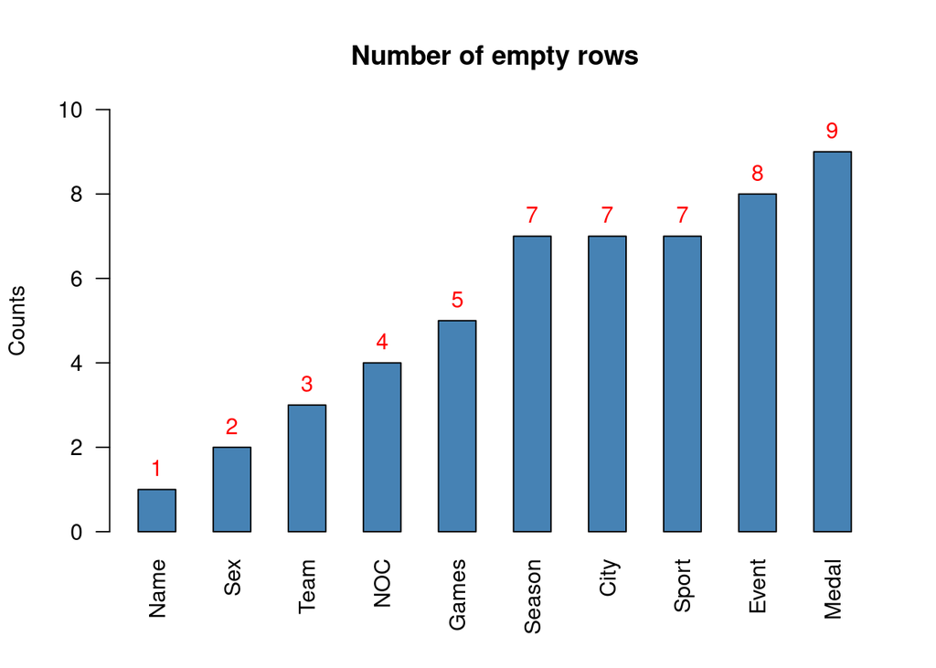

```r
barplot_empty_vals <- barplot(empty_vals_matrix, beside=TRUE,
                              main="Number of empty rows", ylab = "Counts", col='steelblue',
                              cex.names=1., cex.axis=1., cex.lab=1., cex.main=1.2,
                              las=2, ylim=c(0, 10))
text(x = barplot_empty_vals, y = empty_vals_matrix, label = empty_vals, pos = 3, cex=1., col='red')
```

Replace all cells with empty rows with NA

```r
my_data_processed <- my_data %>% mutate(across(everything(), ~replace(.x, .x == '', NA)))
```

Calculate number of NA values in each column

```r
cols_na_percent <- apply(is.na(my_data_processed), 2, function(x) mean(x)*100)
cols_na_percent <- data.frame(cols_na_percent) %>% setNames(c("missing_percent")) %>%
  filter(missing_percent != 0)
cols_na_count <- colSums(is.na(my_data_processed))[colSums(is.na(my_data_processed)) != 0]
```

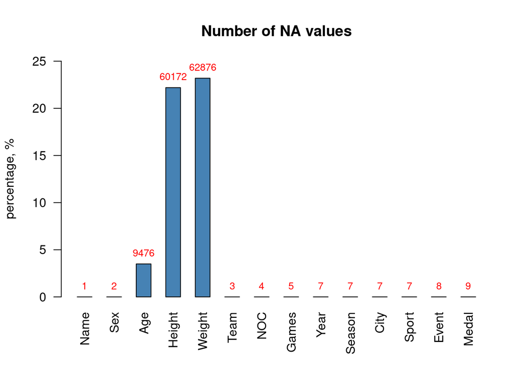

```r
barplot_na_cols <- barplot(t(as.matrix(cols_na_percent)), beside=T,
                           main="Number of NA values", ylab = "percentage, %",
                           col="steelblue", ylim = c(0, 25), las=2,
                           cex.names=1., cex.axis=1., cex.lab=1., cex.main=1.2)
text(x = barplot_na_cols, y = t(as.matrix(cols_na_percent)),
     label = cols_na_count, pos = 3, cex = .8, col='red')
```

Calculate occurence of NA values in rows

```r
rows_na_count <- table(rowSums(is.na(my_data_processed)))
```

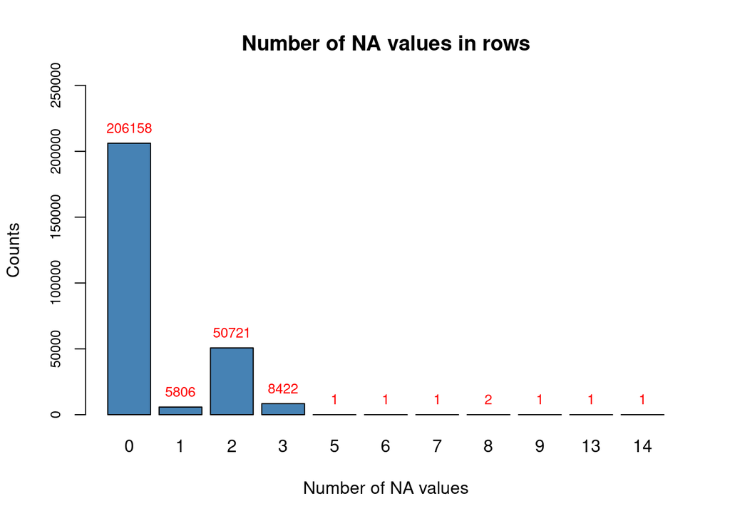

```r
barplot_na_rows <- barplot(rows_na_count, main="Number of NA values in rows",
                           xlab = "Number of NA values", ylab = "Counts",
                           col = "steelblue", ylim = c(0, 250000),
                           cex.names=1., cex.axis=.8, cex.lab=1., cex.main=1.2)
text(x = barplot_na_rows, y = rows_na_count, label = rows_na_count, pos = 3, cex = .8, col='red')
```

Look at the rows with the highest number of NA values

```r
tableHTML(my_data_processed[rowSums(is.na(my_data_processed)) == 14 |
                              rowSums(is.na(my_data_processed)) == 13,])
```

|  | ID | Name | Sex | Age | Height | Weight | Team | NOC | Games | Year | Season | City | Sport | Event | Medal |
| --- | --- | --- | --- | --- | --- | --- | --- | --- | --- | --- | --- | --- | --- | --- | --- |
| 226260 | 113716 | Pietro Spec | NA | NA | NA | NA | NA | NA | NA | NA | NA | NA | NA | NA | NA |
| 248724 | 124516 | NA | NA | NA | NA | NA | NA | NA | NA | NA | NA | NA | NA | NA | NA |

As we can see, almost all information is missing. So, we can drop these rows withot loosing any information

```r
my_data_processed <- my_data_processed[rowSums(is.na(my_data_processed)) != 14 &
                                       rowSums(is.na(my_data_processed)) != 13,]
```

### 3.2. Outliers exploration

### Feature: Sex

We can see that there are some wrong values for Sex feature: not only male and female are present.

```r
unique(my_data_processed$Sex)
```

```
## [1] "M" "F" "G"
```

Look ath this data

```r
tableHTML(my_data_processed %>% filter(is.na(Sex) | Sex == 'G'))
```

|  | ID | Name | Sex | Age | Height | Weight | Team | NOC | Games | Year | Season | City | Sport | Event | Medal |
| --- | --- | --- | --- | --- | --- | --- | --- | --- | --- | --- | --- | --- | --- | --- | --- |
| 1 | 79609 | Pavel Mike | G | 22 | 182 | 79 | Czechoslovakia | TCH | 1972 Summer | 1972 | Summer | Munich | Handball | Handball Men's Handball | Silver |
| 2 | 79630 | Anatoly Mikhaylin | G | 37 | NA | NA | Russia | RUS | 1996 Summer | 1996 | Summer | Atlanta | Sailing | Sailing Mixed Two Person Keelboat | Participant |

Restore people’s gender based on their names

```r
my_data_processed$Sex[my_data_processed$ID == 79609] <- 'M'
my_data_processed$Sex[my_data_processed$ID == 79630] <- 'M'
```

Convert Sex to categorial variable

```r
my_data_processed$Sex <- as.factor(my_data_processed$Sex)
```

### Feature: Height

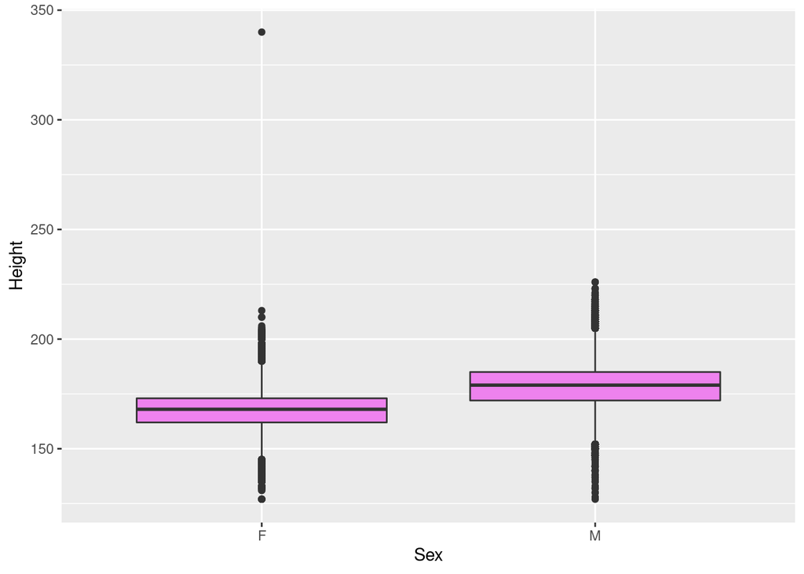

```r
ggplot(my_data_processed, aes(x=Sex, y=Height)) + geom_boxplot(fill='violet')
```

Here we can see too high woman. Obviously, it’s a mistake. So, try to fix it.

```r
height_outlier <- max(my_data_processed$Height, na.rm=T)
tableHTML(my_data_processed %>% filter(Height == height_outlier) %>%
            select(c(ID, Age, NOC, Height, Weight)))
```

|  | ID | Age | NOC | Height | Weight |
| --- | --- | --- | --- | --- | --- |
| 1 | 23549 | 28 | ZIM | 340 | 64 |

There are other notes for this woman (identical IDs), so we can replace this outlier with proper values.

```r
tableHTML(unique(my_data_processed %>% filter(ID == 23549 & Height != height_outlier) %>% select(Height)))
```

|  | Height |
| --- | --- |
| 1 | 176 |

```r
my_data_processed$Height[my_data_processed$Height == height_outlier] <- 176
```

### Feature: Weight

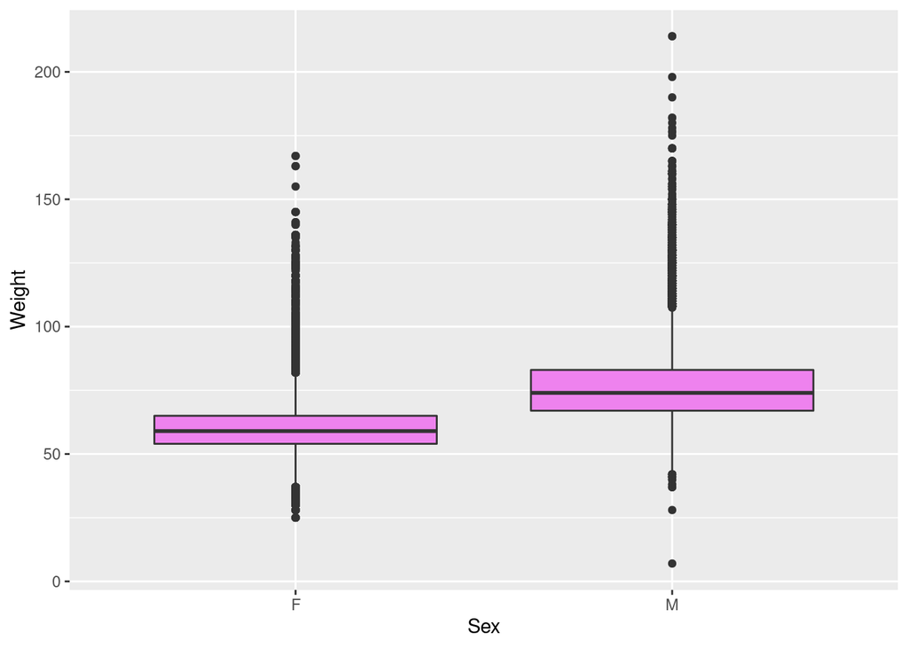

```r
ggplot(my_data_processed, aes(x=Sex, y=Weight)) + geom_boxplot(fill='violet')
```

```r
weight_outlier <- min(my_data_processed$Weight, na.rm=T)
tableHTML(my_data_processed %>% filter(Weight == weight_outlier) %>%
            select(c(ID, Age, NOC, Height, Weight)))
```

|  | ID | Age | NOC | Height | Weight |
| --- | --- | --- | --- | --- | --- |
| 1 | 68370 | 25 | NA | 178 | 7 |

There are other notes for this man (identical IDs), so we can replace this outlier with proper values.

```r
tableHTML(unique(my_data_processed %>%
                   filter(ID == 68370 & Weight != weight_outlier) %>% select(Weight)))
```

|  | Weight |
| --- | --- |
| 1 | 77 |

```r
my_data_processed$Weight[my_data_processed$Weight == weight_outlier] <- 77
```

### Feature: Age

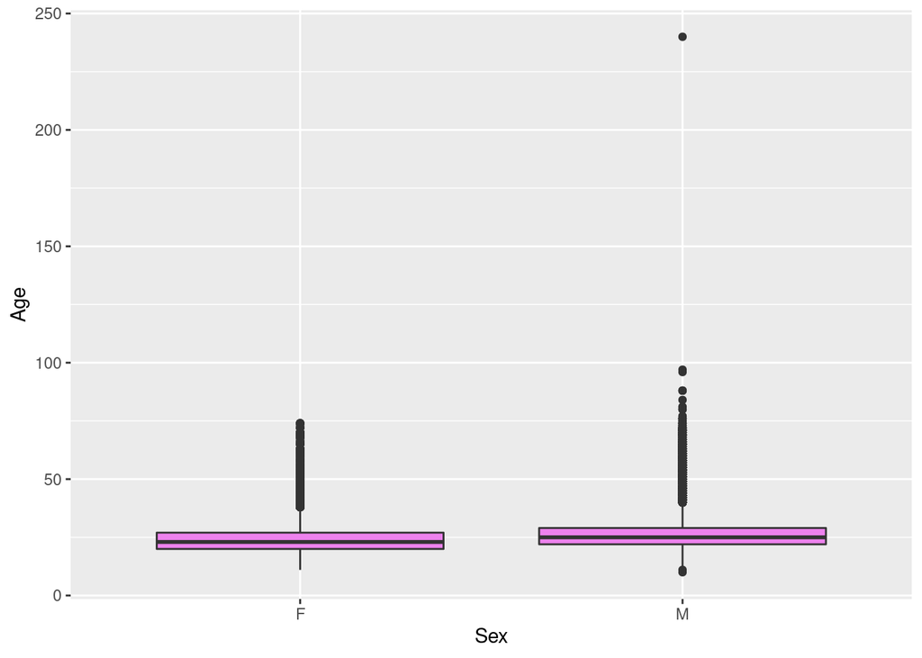

```r
ggplot(my_data_processed, aes(x=Sex, y=Age)) + geom_boxplot(fill='violet')
```

Here we can see very old man. People can not leave so long, so it’s a mistake.

```r
age_outlier <- max(my_data_processed$Age, na.rm=T)
tableHTML(my_data_processed %>% filter(Age == age_outlier) %>%
            select(c(ID, Age, Year, Sport)))
```

|  | ID | Age | Year | Sport |
| --- | --- | --- | --- | --- |
| 1 | 23459 | 240 | 1912 | Swimming |

We can see that this man took part in several competitions during 1912. And he was 24 year old at that time.

```r
tableHTML(my_data_processed %>% filter(ID == 23459 & Year == 1912))
```

|  | ID | Name | Sex | Age | Height | Weight | Team | NOC | Games | Year | Season | City | Sport | Event | Medal |
| --- | --- | --- | --- | --- | --- | --- | --- | --- | --- | --- | --- | --- | --- | --- | --- |
| 1 | 23459 | Flicien Jules mile Courbet | M | 24 | NA | NA | Belgium | BEL | 1912 Summer | 1912 | Summer | Stockholm | Water Polo | Water Polo Men's Water Polo | Bronze |
| 2 | 23459 | Flicien Jules mile Courbet | M | 240 | NA | NA | Belgium | BEL | 1912 Summer | 1912 | Summer | Stockholm | Swimming | Swimming Men's 200 metres Breaststroke | Participant |
| 3 | 23459 | Flicien Jules mile Courbet | M | 24 | NA | NA | Belgium | BEL | 1912 Summer | 1912 | Summer | Stockholm | Swimming | Swimming Men's 400 metres Breaststroke | Participant |

So, replace this outlier with proper age

```r
my_data_processed$Age[my_data_processed$Age == age_outlier] <- 24
```

### 3.3. Filling missing data

Group people by their Sex and Team and for each resulting group calculate median values for Age, Height, Weight. Fill NA values in this columns with medians of corresponding groups.

```r
my_data_processed <- my_data_processed %>% group_by(Team, Sex) %>%
    mutate(across(c('Age', 'Weight', 'Height'), ~replace_na(.x, median(.x, na.rm=T))))
```

Nevetherless, we can see that there are still NA values because not for each NA value corresponding group was found.

```r
colSums(is.na(my_data_processed[,c('Weight', 'Height', 'Age')]))
```

```
## Weight Height    Age
##   2448   2255    323
```

Then, let’s group participants just by Sex variable. And replace remaining NAs with medians in this groups.

```r
my_data_processed <- my_data_processed  %>% group_by(Sex) %>%
    mutate(across(c('Age', 'Weight', 'Height'), ~replace_na(.x, median(.x, na.rm=T))))
```

As we can see, all NA values disappeared

```r
colSums(is.na(my_data_processed[,c('Weight', 'Height', 'Age')]))
```

```
## Weight Height    Age
##      0      0      0
```

During calculation of medians and filling NA values, variables Age, Height, Weight were converted to doubles. So, let’s convert them back to integers.

```r
my_data_processed$Height <- as.integer(my_data_processed$Height)
my_data_processed$Weight <- as.integer(my_data_processed$Weight)
my_data_processed$Age <- as.integer(my_data_processed$Age)
```

Visualize remaining rows containing NA values in data frame.

```r
colSums(is.na(my_data_processed[,c('Weight', 'Height', 'Age')]))
```

```
## Weight Height    Age
##      0      0      0
```

There are only 7 rows with NA values. So, we can conclude that almost all data was successfully cleaned.

```r
tableHTML(my_data_processed[!complete.cases(my_data_processed), ])
```

|  | ID | Name | Sex | Age | Height | Weight | Team | NOC | Games | Year | Season | City | Sport | Event | Medal |
| --- | --- | --- | --- | --- | --- | --- | --- | --- | --- | --- | --- | --- | --- | --- | --- |
| 1 | 12005 | Andrea Melissa Blackett | F | 24 | 167 | 59 | Barbados | BAR | 2000 Su | NA | NA | NA | NA | NA | NA |
| 2 | 23433 | Hadj Moussa Coulibaly | M | 23 | 182 | 79 | Mali | MLI | 2004 Summe | NA | NA | NA | NA | NA | NA |
| 3 | 34727 | Carlotta Ferlito | F | 17 | 160 | 50 | Italy | NA | NA | NA | NA | NA | NA | NA | NA |
| 4 | 45919 | Yuka Harada | F | 28 | 170 | 60 | Japan | JP | NA | NA | NA | NA | NA | NA | NA |
| 5 | 57367 | Velik Nikolov Kapsazov | M | 25 | 167 | 67 | Bulgaria | BUL | 1960 Summer | 1960 | Summer | Roma | Gymnastics | Gymnastics M | NA |
| 6 | 68370 | Helmut Lehmann | M | 25 | 178 | 77 | NA | NA | NA | NA | NA | NA | NA | NA | NA |
| 7 | 91137 | Georgios Pantos | M | 25 | 180 | 75 | Athens-2 | GRE | 1906 Summer | 1906 | Summer | Athina | Footba | NA | NA |

## 4. Exploratory Data Analysis

Look at gender proportions

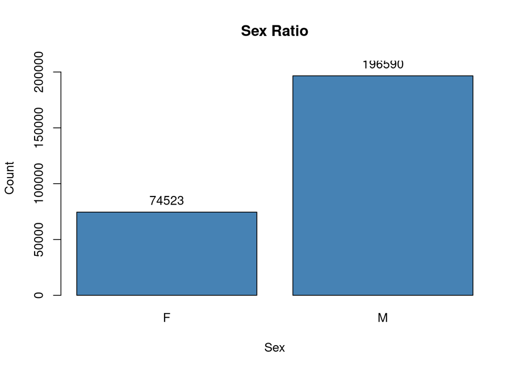

```r
barplot_sex <- barplot(table(my_data_processed$Sex), beside=TRUE,
                       main="Sex Ratio", ylim = c(0, 210000),
                       xlab='Sex', ylab = "Count", col="steelblue",
                       cex.names=1., cex.axis=1., cex.lab=1., cex.main=1.2)
text(x = barplot_sex, y = table(my_data_processed$Sex),
     label = table(my_data_processed$Sex), pos = 3, cex = 1.)
```

Visualize Height and Weight relationship.

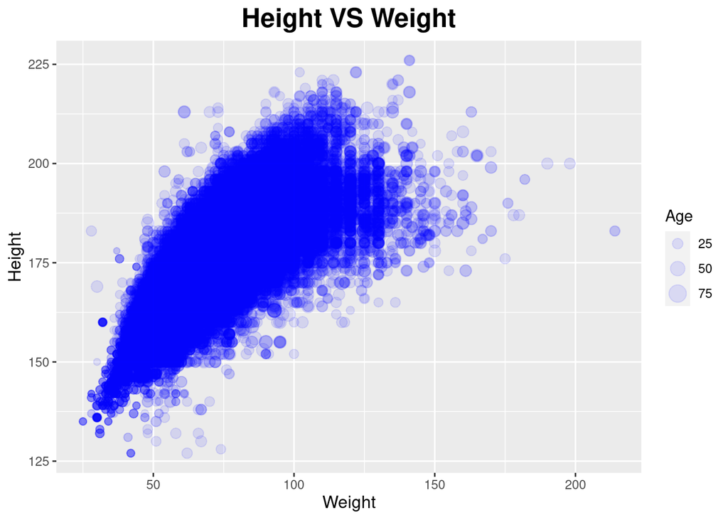

```r
ggplot(my_data_processed, aes(Weight, Height, size=Age)) +
  geom_point(color='blue', alpha=0.1) + ggtitle('Height VS Weight') +
    theme(
    plot.title = element_text(size=18, face="bold", hjust=.5),
    axis.title.x = element_text(size=12),
    axis.title.y = element_text(size=12)
    )
```

Look at the participants with large weights situated far away from other dots

```r
tableHTML(my_data_processed %>% ungroup() %>% arrange(desc(Weight)) %>%
            select(Weight,Sport) %>% slice(1:5))
```

|  | Weight | Sport |
| --- | --- | --- |
| 1 | 214 | Judo |
| 2 | 214 | Judo |
| 3 | 198 | Judo |
| 4 | 190 | Wrestling |
| 5 | 182 | Wrestling |

People with large weights do Judo and Wrestling. And there is nothing unususal normal such kinds of sport.

Look at basic statistics of numeric variables

```r
descr <- psych::describe(select_if(my_data_processed %>% ungroup(), is.numeric), fast=TRUE)
tableHTML(descr)
```

|  | vars | n | mean | sd | min | max | range | se |
| --- | --- | --- | --- | --- | --- | --- | --- | --- |
| ID | 1 | 271113 | 68248.4533939723 | 39022.1999746203 | 1 | 135571 | 135570 | 74.9439499182382 |
| Age | 2 | 271113 | 25.541836798678 | 6.29540713366522 | 10 | 97 | 87 | 0.0120906221906295 |
| Height | 3 | 271113 | 175.892376979341 | 9.59707176885597 | 127 | 226 | 99 | 0.0184316226782362 |
| Weight | 4 | 271113 | 71.227890215519 | 12.9501703043272 | 25 | 214 | 189 | 0.0248714043634491 |
| Year | 5 | 271108 | 1978.37831417738 | 29.8775791810919 | 1896 | 2016 | 120 | 0.0573818095152611 |

Then, look at the correlation of numeric variables

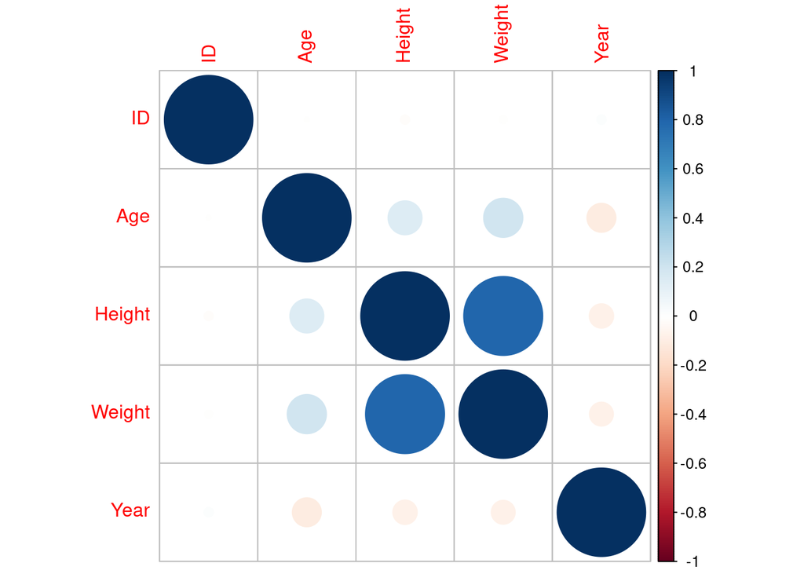

```r
correlation_data <- cor(select_if(my_data_processed %>% ungroup(), is.numeric),
                        use="complete.obs")
corrplot::corrplot(correlation_data)
```

## 5. Deep Data Analysis

### Check the youngest participants (Olympiad 1992)

```r
tableHTML(my_data_processed %>% group_by(Sex) %>% filter(Year == 1992) %>%
            summarize(min_age=min(Age)))
```

|  | Sex | min_age |
| --- | --- | --- |
| 1 | F | 12 |
| 2 | M | 11 |

### Check statistics of Height variable (meand and sd)

```r
tableHTML(my_data_processed %>% group_by(Sex) %>% summarize(mean=round(mean(Height), 1),
                                                            sd=round(sd(Height), 1)))
```

|  | Sex | mean | sd |
| --- | --- | --- | --- |
| 1 | F | 167.8 | 8.4 |
| 2 | M | 178.9 | 8.2 |

### Check statistics of Height variable for female tennis players (Olympiad 2000)

```r
tableHTML(my_data_processed %>% ungroup() %>%
            filter(Year == 2000 & Sex == 'F' & Sport == 'Tennis') %>%
            summarize(mean=round(mean(Height), 1), sd=round(sd(Height), 1)))
```

|  | mean | sd |
| --- | --- | --- |
| 1 | 171.7 | 6.5 |

```r
tableHTML(my_data_processed %>% ungroup() %>% filter(Year == 2006)
          %>% summarize(max=max(Sport)))
```

|  | max |
| --- | --- |
| 1 | Speed Skating |

```r
tableHTML(my_data_processed %>% group_by(Sex) %>%
            filter(1980 <= Year & Year <= 2010 & Medal == 'Gold' & Sex == 'F') %>% count())
```

|  | Sex | n |
| --- | --- | --- |
| 1 | F | 2249 |

### Calculate number of John Aalberg’s participations during different years

```r
tableHTML(my_data_processed %>% group_by(Year) %>%
            filter(Name == "John Aalberg") %>% count())
```

|  | Year | n |
| --- | --- | --- |
| 1 | 1992 | 4 |
| 2 | 1994 | 4 |

### Check the most and the least represented (by number of participants) age groups

```r
find_age_groups <- function(data, lower_bound, upper_bound, year){
    n_group <- data %>% group_by(ID) %>%
      filter(Age >= lower_bound & Age < upper_bound & Year == year) %>%
        count()
    return(nrow(n_group))
}
```

```r
group_1 <- find_age_groups(my_data_processed, 15, 25, 2008)
paste("Group from 15 to 25 years:", group_1, "participants", sep = " ")
```

```
## [1] "Group from 15 to 25 years: 4787 participants"
```

```r
group_2 <- find_age_groups(my_data_processed, 25, 35, 2008)
paste("Group from 25 to 35 years:", group_2, "participnats", sep = " ")
```

```
## [1] "Group from 25 to 35 years: 5382 participnats"
```

```r
group_3 <- find_age_groups(my_data_processed, 35, 45, 2008)
paste("Group from 35 to 45 years:", group_3, "participants", sep = " ")
```

```
## [1] "Group from 35 to 45 years: 630 participants"
```

```r
group_4 <- find_age_groups(my_data_processed, 45, 55, 2008)
paste("Group from 45 to 55 years:", group_4, "participants", sep = " ")
```

```
## [1] "Group from 45 to 55 years: 76 participants"
```

```r
group_5 <- find_age_groups(my_data_processed, 55, 70, 2008)
paste("Group from 55 to 70 years:", group_5, "participants", sep = " ")
```

```
## [1] "Group from 55 to 70 years: 11 participants"
```

### Check changes in sports nmber for 2002 year compared to 1994

```r
sports_1994 <- my_data_processed %>% filter(Year == 1994) %>% ungroup() %>% select(Sport)
sports_2002 <- my_data_processed %>% filter(Year == 2002) %>% ungroup() %>% select(Sport)
nrow(unique(sports_2002))-nrow(unique(sports_1994))
```

```
## [1] 3
```

```r
find_top_countries <- function(data, season, n_top){
    df_medals <- data %>% group_by(Season, Medal, NOC) %>% filter(Season == season) %>%
      count(Medal) %>% arrange(desc(n))
    df_gold <- head(df_medals[df_medals$Medal == "Gold",], n_top)
    df_silver <- head(df_medals[df_medals$Medal == "Silver",], n_top)
    df_bronze <- head(df_medals[df_medals$Medal == "Bronze",], n_top)
    df_top <- rbind(df_gold, df_silver, df_bronze)
    return(df_top)
}
```

Top 3 countries for summer Olympiad (for each type of medal)

```r
tableHTML(find_top_countries(na.omit(my_data_processed), 'Summer', 3))
```

|  | Season | Medal | NOC | n |
| --- | --- | --- | --- | --- |
| 1 | Summer | Gold | USA | 2472 |
| 2 | Summer | Gold | URS | 832 |
| 3 | Summer | Gold | GBR | 636 |
| 4 | Summer | Silver | USA | 1333 |
| 5 | Summer | Silver | GBR | 729 |
| 6 | Summer | Silver | URS | 635 |
| 7 | Summer | Bronze | USA | 1197 |
| 8 | Summer | Bronze | GER | 649 |
| 9 | Summer | Bronze | GBR | 620 |

```r
tableHTML(find_top_countries(na.omit(my_data_processed), 'Summer', 3))
```

[output not shown]

### Height standartization (z-score)

Add new column with Height standartized by z-score

```r
z_score_scaling  <- function(x){
    z_scores <- (x-mean(x))/sd(x)
    return(z_scores)
}

my_data_processed <- my_data_processed %>% mutate(Height_z_scores = z_score_scaling(Height))
```

### Height standartization (min_max score)

Add new column with Height standartized by min_max score

```r
min_max_scaling <- function(x){
    min_max_scores <- (x-min(x))/(max(x)-min(x))
    return(min_max_scores)
}

my_data_processed <- my_data_processed %>% mutate(Height_min_max_scaled=min_max_scaling(Height))
```

Look at new variables

```r
tableHTML(my_data_processed %>% ungroup() %>%
            select(Height_z_scores, Height_min_max_scaled) %>% slice(1:5))
```

|  | Height_z_scores | Height_min_max_scaled |
| --- | --- | --- |
| 1 | 0.129628791971047 | 0.535353535353535 |
| 2 | -1.09676485816265 | 0.434343434343434 |
| 3 | 0.374907521997786 | 0.555555555555556 |
| 4 | 0.129628791971047 | 0.535353535353535 |
| 5 | 2.04507007829589 | 0.674418604651163 |

### Height comparisons between male and female (winter Olympiad)

Make subset with only winter Olympiads

```r
my_data_processed_winter <- my_data_processed %>% filter(Season == "Winter")
```

- **H0**: there is no difference in heights between male and female groups
- **H1**: there is a difference in heights between male and female groups

We will use nonparametric Wilcoxon test.

```r
wilcox.test(Height ~ Sex, my_data_processed_winter)
```

```
##
##  Wilcoxon rank sum test with continuity correction
##
## data:  Height by Sex
## W = 37274604, p-value < 2.2e-16
## alternative hypothesis: true location shift is not equal to 0
```

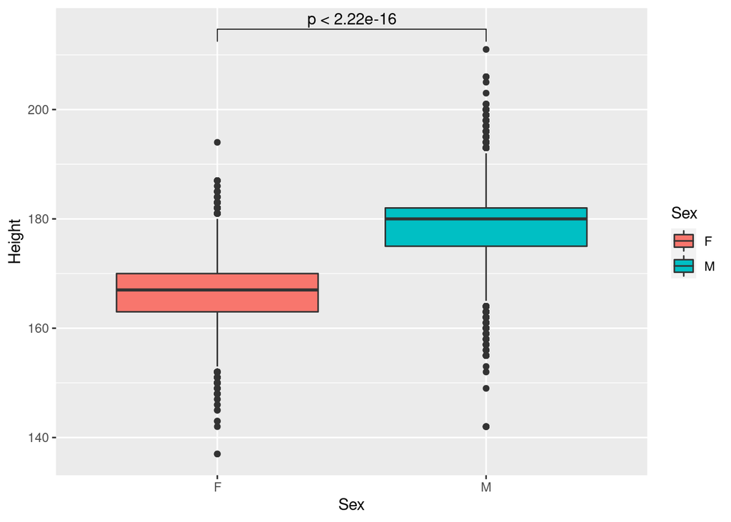

```r
ggplot(my_data_processed_winter, aes(x=Sex, y=Height, fill=Sex)) +
    geom_boxplot() + stat_compare_means(method = "wilcox.test", comparisons=list(c('F', 'M')))
```

**Conclusion:** p-value is less than 0.05 so we can reject the null-hypothesis and say that there is a statistical difference in heights between male and female groups

### Weight comparisons between male and female (winter Olympiad)

- **H0**: there is no difference in weights between male and female groups
- **H1**: there is a difference in weights between male and female groups

We will use nonparametric Wilcoxon test.

```r
wilcox.test(Weight ~ Sex, my_data_processed_winter)
```

```
##
##  Wilcoxon rank sum test with continuity correction
##
## data:  Weight by Sex
## W = 34411126, p-value < 2.2e-16
## alternative hypothesis: true location shift is not equal to 0
```

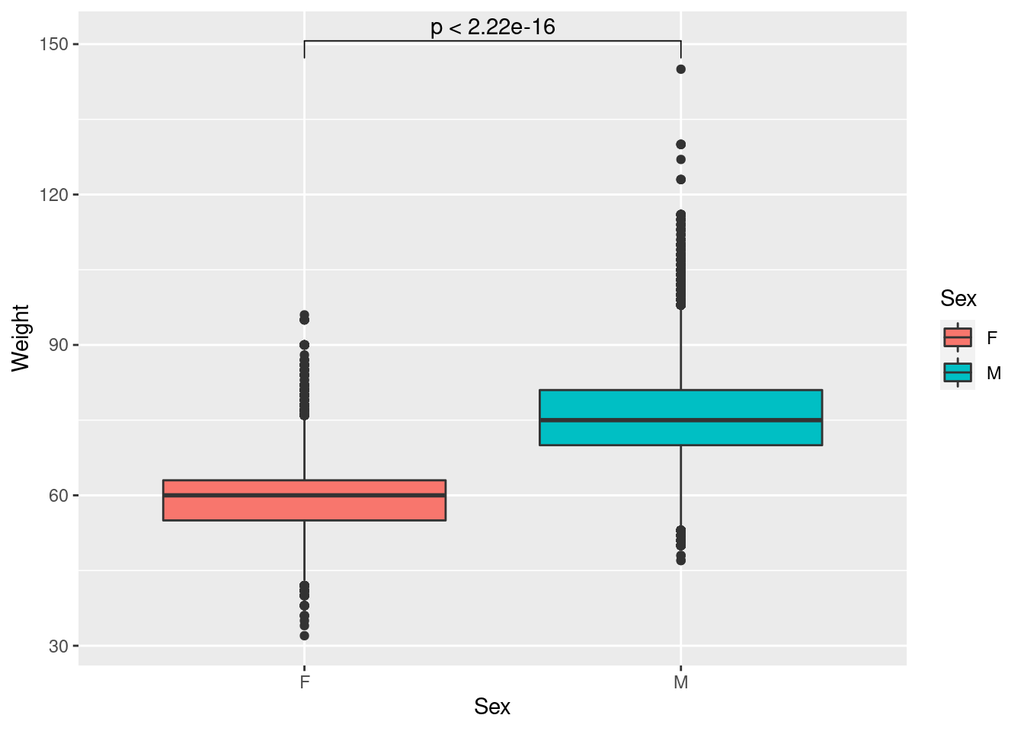

```r
ggplot(my_data_processed_winter, aes(x=Sex, y=Weight, fill=Sex)) +
    geom_boxplot() + stat_compare_means(method = "wilcox.test", comparisons=list(c('F', 'M')))
```

**Conclusion:** p-value is less than 0.05 so we can reject the null-hypothesis and say that there is a statistical difference in weights between male and female groups

### Age comparisons between male and female (winter Olympiad)

- **H0**: there is no difference in ages between male and female groups
- **H1**: there is a difference in ages between male and female groups

We will use nonparametric Wilcoxon test.

```r
wilcox.test(Age ~ Sex, my_data_processed_winter)
```

```
##
##  Wilcoxon rank sum test with continuity correction
##
## data:  Age by Sex
## W = 207613314, p-value < 2.2e-16
## alternative hypothesis: true location shift is not equal to 0
```

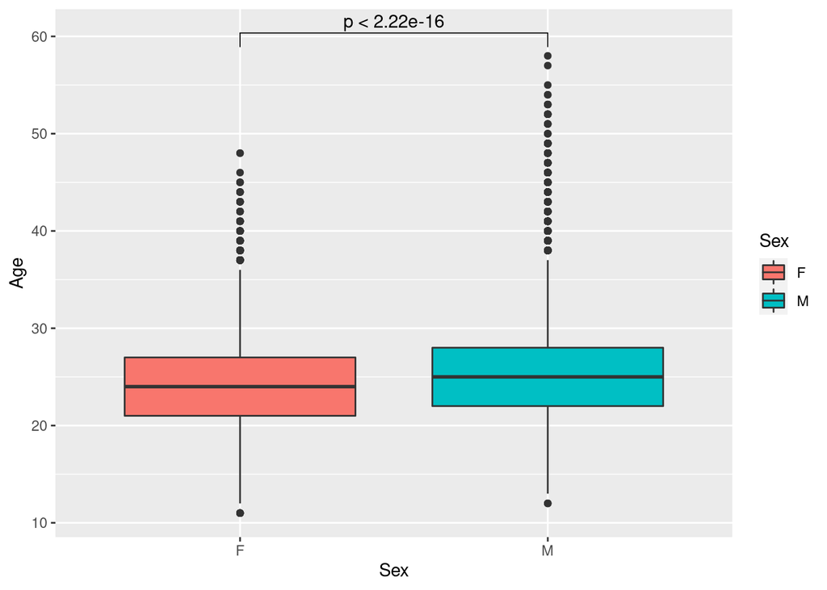

```r
ggplot(my_data_processed_winter, aes(x=Sex, y=Age, fill=Sex)) +
    geom_boxplot() + stat_compare_means(method = "wilcox.test", comparisons=list(c('F', 'M')))
```

**Conclusion:** p-value is less than 0.05 so we can reject the null-hypothesis and say that there is a statistical difference in ages between male and female groups

### Look at the connection between Team and Medal features

- **H0:** there is no connection between team and medal features (distribution does not differ from random)
- **H1:** there is some connection between team and medal features (distribution differs from random)

We will use nonparametric Fisher test because many of the expected values will be very small. Implement this test with additional parameter **simulate.p.value = TRUE**: a logical indicating whether to compute p-values by Monte Carlo simulation, in larger than 2 by 2 tables.

```r
my_data_subset <- na.omit(my_data_processed) %>% select(Team, Medal)
team_medal_table <- table(my_data_subset$Team, my_data_subset$Medal)
fisher.test(team_medal_table, simulate.p.value = TRUE)
```

```
##
##  Fisher's Exact Test for Count Data with simulated p-value (based on
##  2000 replicates)
##
## data:  team_medal_table
## p-value = 0.0004998
## alternative hypothesis: two.sided
```

- **Conclusion:** p-value is less than 0.05 so we can reject the null-hypothesis and say that empirical distribution statistically differs from random distribution, so there is a connection between teams and medals which they obtained.